# Term Deposit Subscription Prediction Analysis

#### Visualizing the Distribution of the Variables

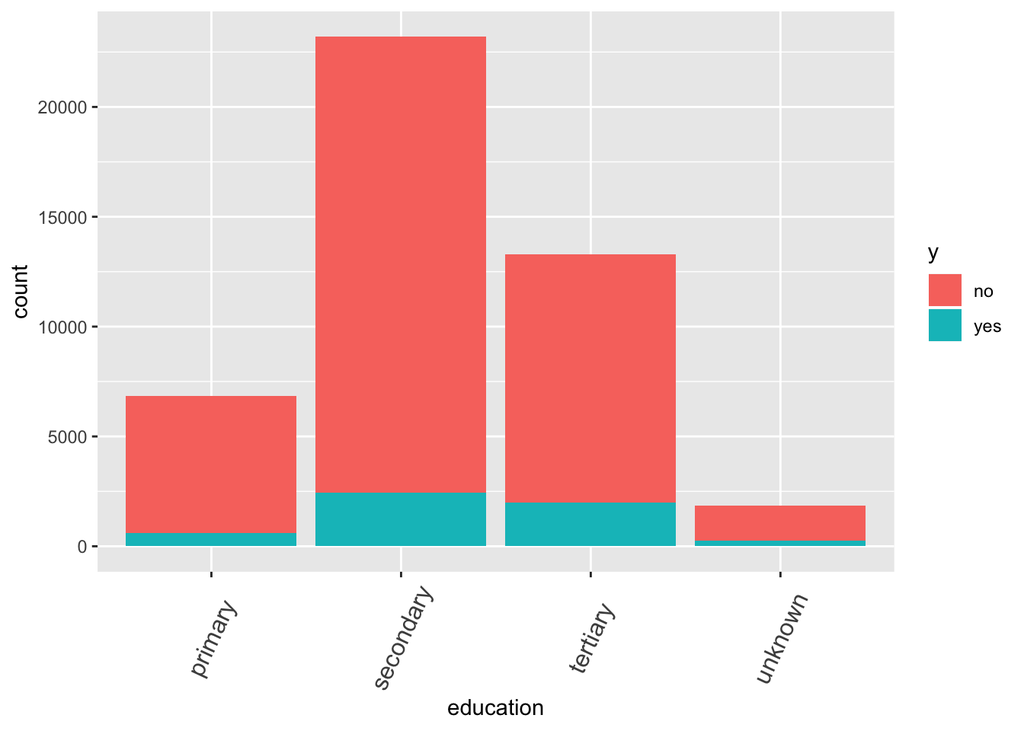

```r
data %>%
    ggplot(aes(education)) +
    geom_bar(aes(fill=y)) +
    theme( axis.text.x = element_text(angle = 65,vjust = 0.5, hjust = 0.5, size = 12))
```

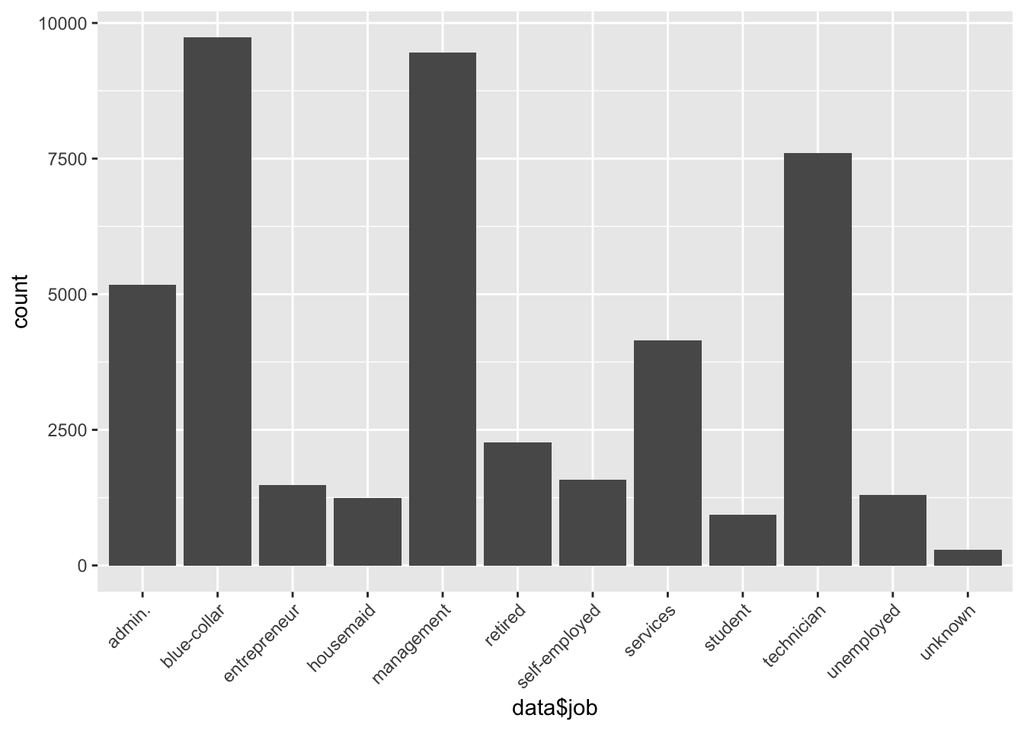

```r
data %>%
    ggplot(aes(data$job)) +
    geom_bar() +
    theme(axis.text.x = element_text(angle = 45, hjust = 1))
```

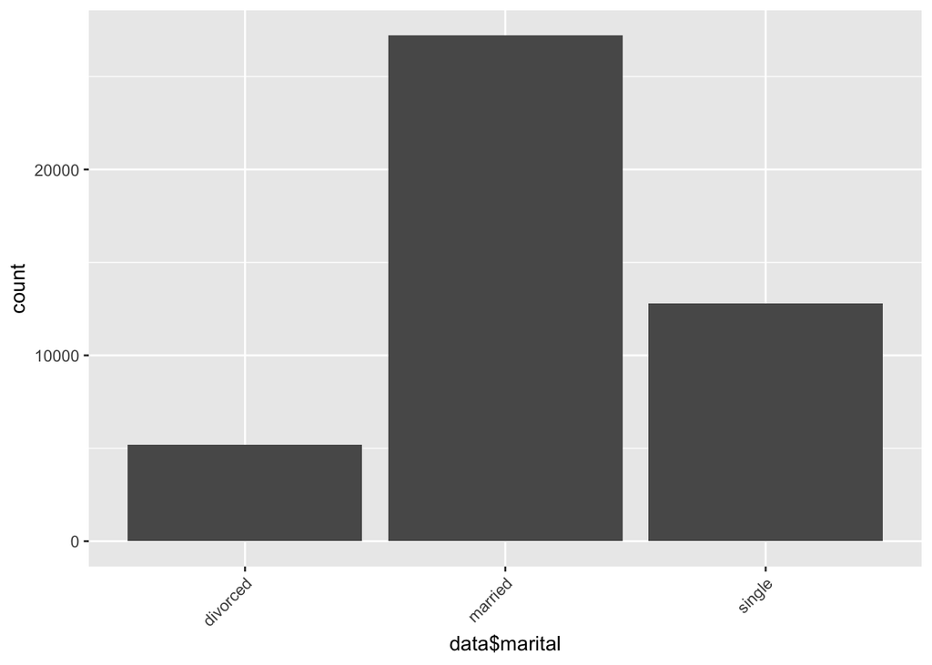

```r
data %>%
    ggplot(aes(data$marital)) +
    geom_bar() +
    theme(axis.text.x = element_text(angle = 45, hjust = 1))
```

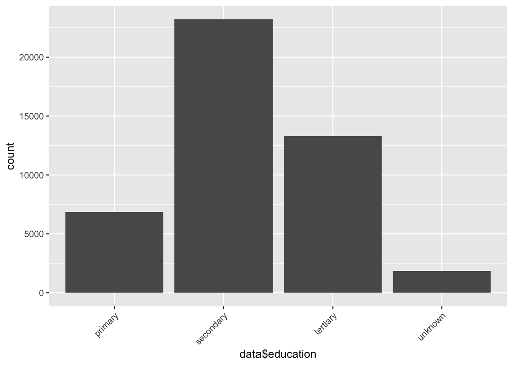

```r
data %>%
    ggplot(aes(data$education)) +
    geom_bar() +
    theme(axis.text.x = element_text(angle = 45, hjust = 1))
```

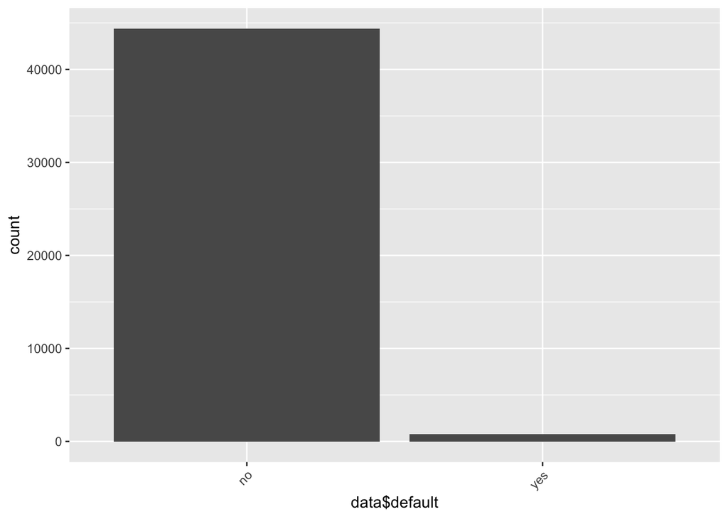

```r
data %>%
    ggplot(aes(data$default)) +
    geom_bar() +
    theme(axis.text.x = element_text(angle = 45, hjust = 1))
```

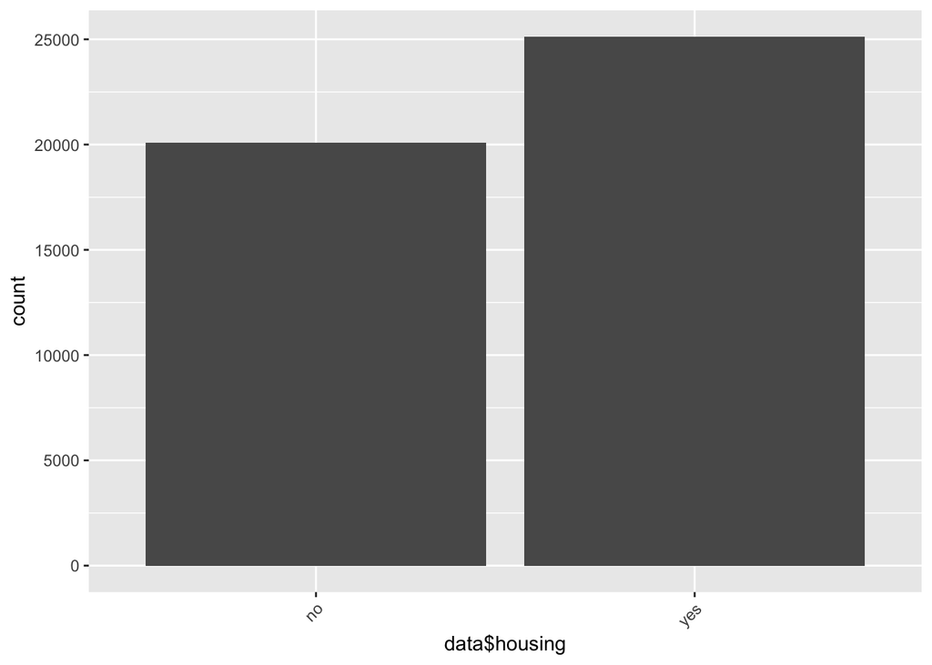

```r
data %>%
    ggplot(aes(data$housing)) +
    geom_bar() +
    theme(axis.text.x = element_text(angle = 45, hjust = 1))
```

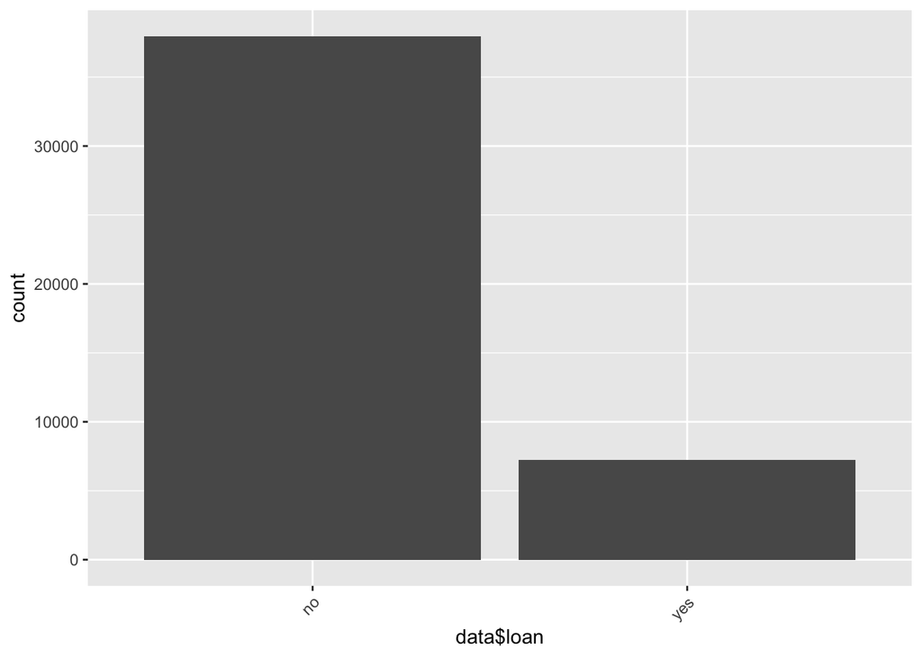

```r
data %>%
    ggplot(aes(data$loan)) +
    geom_bar() +
    theme(axis.text.x = element_text(angle = 45, hjust = 1))
```

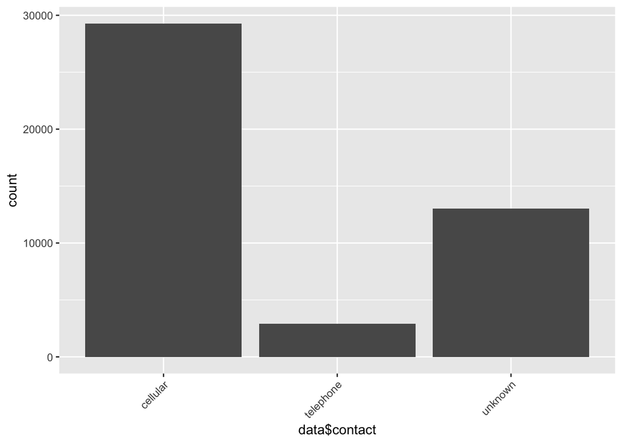

```r
data %>%
    ggplot(aes(data$contact)) +
    geom_bar() +
    theme(axis.text.x = element_text(angle = 45, hjust = 1))
```

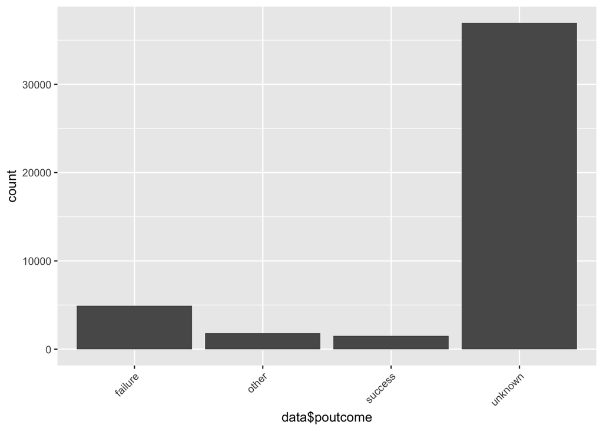

```r
data %>%
    ggplot(aes(data$poutcome)) +
    geom_bar() +
    theme(axis.text.x = element_text(angle = 45, hjust = 1))
```

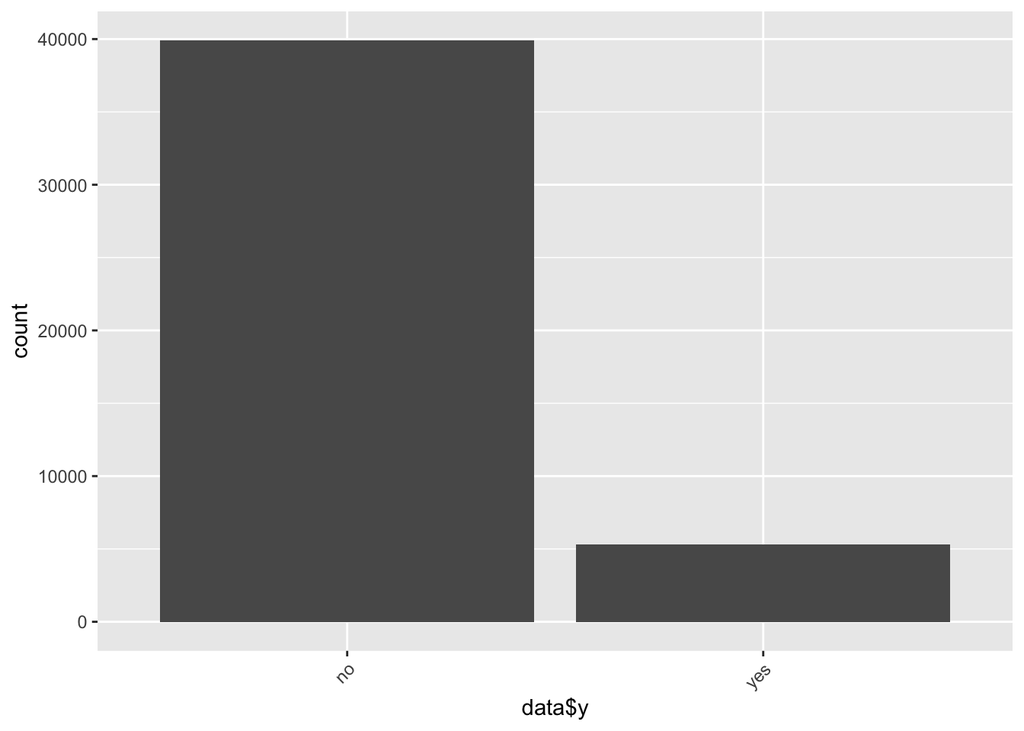

```r
data %>%
    ggplot(aes(data$y)) +
    geom_bar() +
    theme(axis.text.x = element_text(angle = 45, hjust = 1))
```

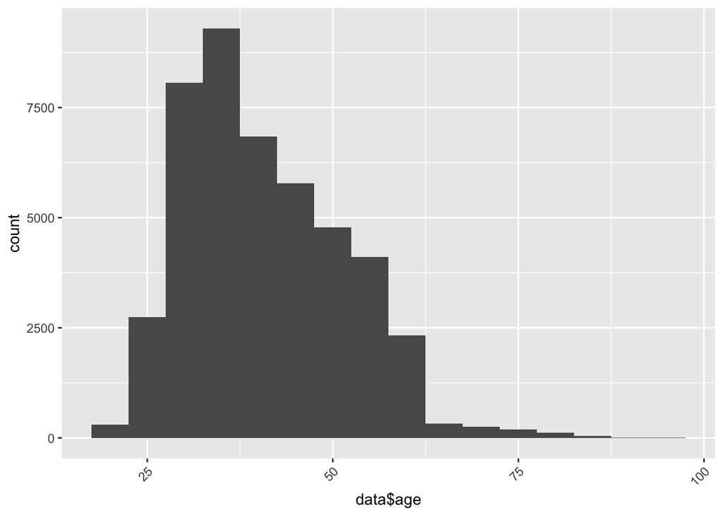

```r
data %>%
    ggplot(aes(data$age)) +
    geom_histogram(binwidth = 5) +
    theme(axis.text.x = element_text(angle = 45, hjust = 1))
```

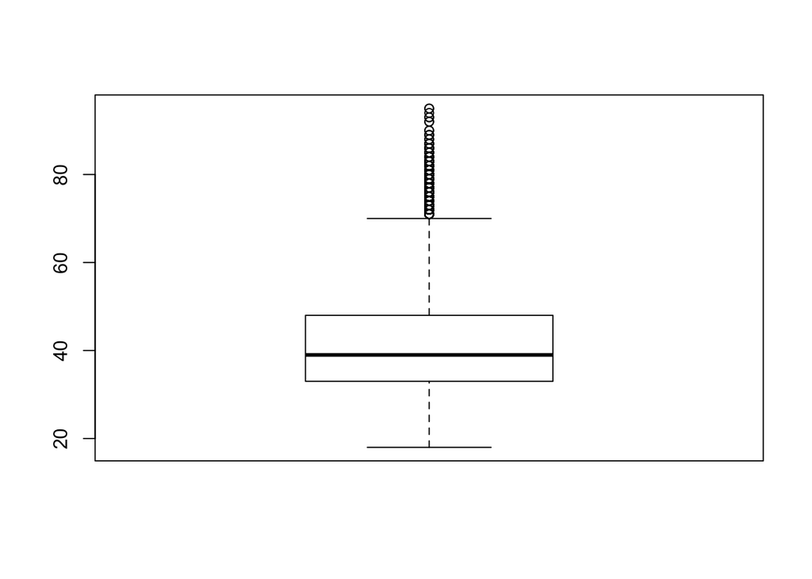

```r
boxplot(data$age)
```

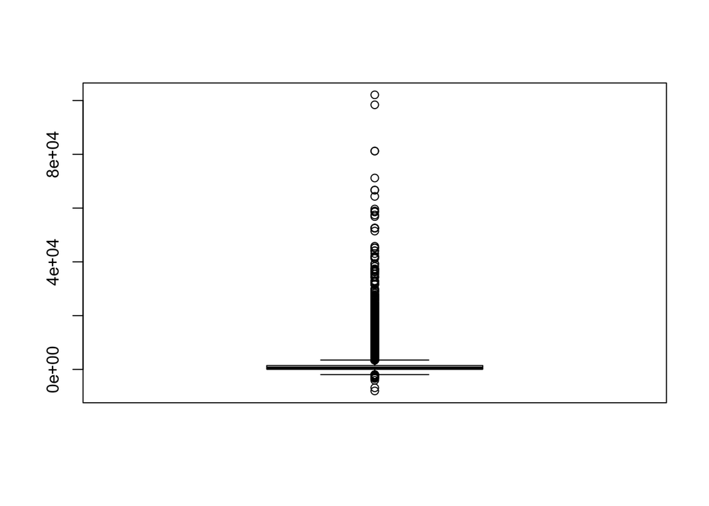

```r
boxplot(data$balance)
```

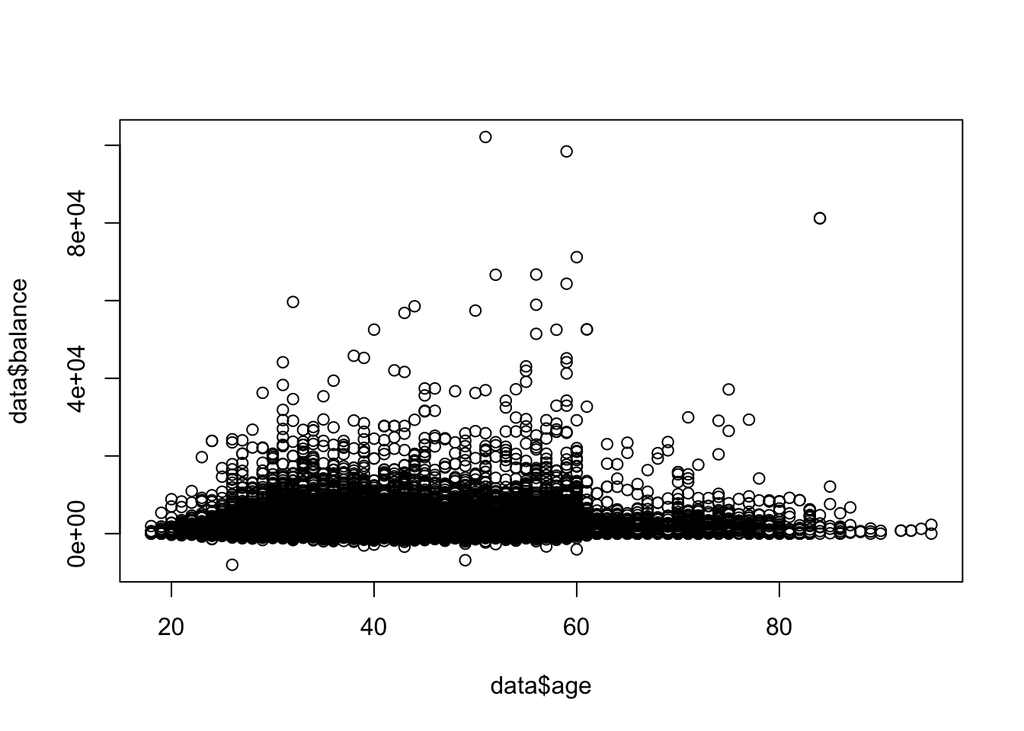

```r
plot(data$age, data$balance)
```

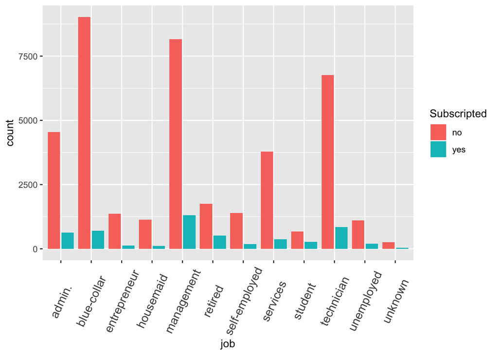

```r
data %>%
    ggplot(aes(x=job, fill=y))+
    geom_bar(position="dodge2")+
    guides(fill=guide_legend(title="Subscripted")) +
    theme( axis.text.x = element_text(angle = 65,vjust = 0.5, hjust = 0.5, size = 12))
```

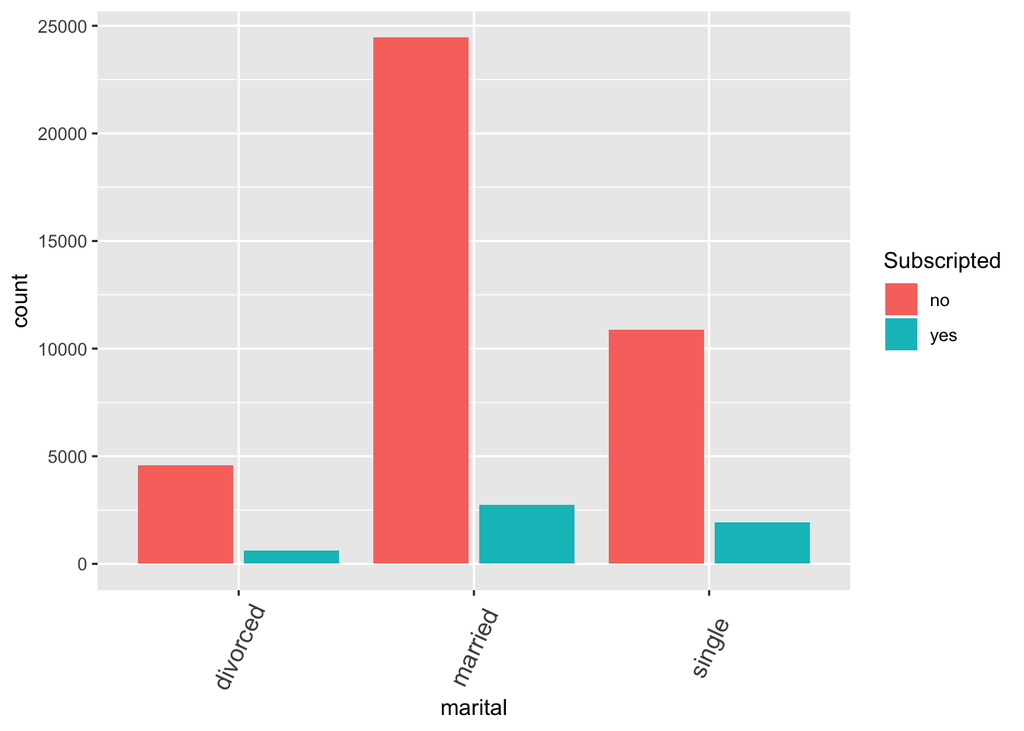

```r
data %>%
    ggplot(aes(x=marital, fill=y))+
    geom_bar(position="dodge2")+
    guides(fill=guide_legend(title="Subscripted")) +
    theme( axis.text.x = element_text(angle = 65,vjust = 0.5, hjust = 0.5, size = 12))
```

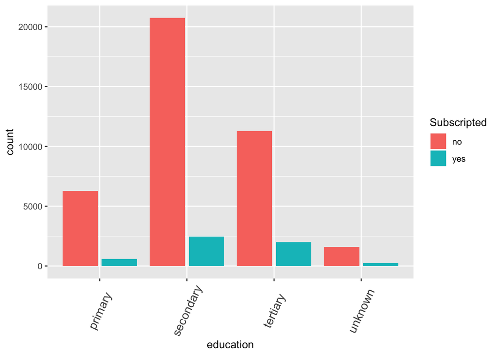

```r
data %>%
    ggplot(aes(x=education, fill=y))+
    geom_bar(position="dodge2")+
    guides(fill=guide_legend(title="Subscripted")) +
    theme( axis.text.x = element_text(angle = 65,vjust = 0.5, hjust = 0.5, size = 12))
```

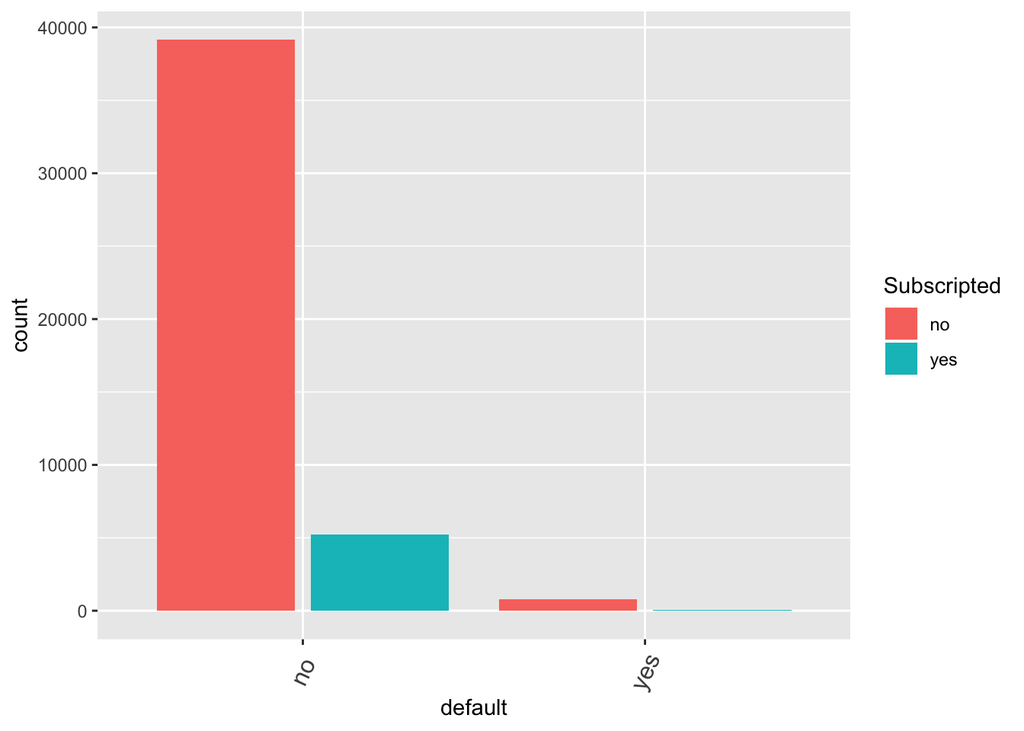

```r
data %>%
    ggplot(aes(x=default, fill=y))+
    geom_bar(position="dodge2")+
    guides(fill=guide_legend(title="Subscripted")) +
    theme( axis.text.x = element_text(angle = 65,vjust = 0.5, hjust = 0.5, size = 12))
```

```r
data %>%
    group_by(job) %>%
    summarise(yes=sum(y=="yes"), no= sum(y=="no"),
              yes_pct=round(yes*100/(yes+no),2),
              no_pct=round(no*100/(yes+no),2))%>%
    arrange(job) %>%
    select(-yes, -no)
```

```
## # A tibble: 12 x 3
##    job           yes_pct no_pct
##    <fct>           <dbl>  <dbl>
##  1 admin.          12.2    87.8
##  2 blue-collar      7.27   92.7
##  3 entrepreneur     8.27   91.7
##  4 housemaid        8.79   91.2
##  5 management      13.8    86.2
##  6 retired         22.8    77.2
##  7 self-employed   11.8    88.2
##  8 services         8.88   91.1
##  9 student         28.7    71.3
## 10 technician      11.1    88.9
## 11 unemployed      15.5    84.5
## 12 unknown         11.8    88.2
```

```r
groups <- c(quo(job), quo(marital), quo(education), quo(default),
            quo(housing), quo(loan), quo(contact), quo(poutcome))

for (i in seq_along(groups)) {
  data %>%
    group_by(!!groups[[i]]) %>%
    summarise(yes=sum(y=="yes"), no= sum(y=="no"),
              yes_pct=round(yes*100/(yes+no),2),
              no_pct=round(no*100/(yes+no),2))%>%
    arrange(!!groups[[i]]) %>%
    select(-yes, -no) %>%
    print()
    cat('\n')
}
```

```
## # A tibble: 12 x 3
##    job           yes_pct no_pct
##    <fct>           <dbl>  <dbl>
##  1 admin.          12.2    87.8
##  2 blue-collar      7.27   92.7
##  3 entrepreneur     8.27   91.7
##  4 housemaid        8.79   91.2
##  5 management      13.8    86.2
##  6 retired         22.8    77.2
##  7 self-employed   11.8    88.2
##  8 services         8.88   91.1
##  9 student         28.7    71.3
## 10 technician      11.1    88.9
## 11 unemployed      15.5    84.5
## 12 unknown         11.8    88.2
##
## # A tibble: 3 x 3
##   marital  yes_pct no_pct
##   <fct>      <dbl>  <dbl>
## 1 divorced    12.0   88.0
## 2 married     10.1   89.9
## 3 single      15.0   85.0
##
## # A tibble: 4 x 3
##   education yes_pct no_pct
##   <fct>       <dbl>  <dbl>
## 1 primary      8.63   91.4
## 2 secondary   10.6    89.4
## 3 tertiary    15.0    85.0
## 4 unknown     13.6    86.4
##
## # A tibble: 2 x 3
##   default yes_pct no_pct
##   <fct>     <dbl>  <dbl>
## 1 no        11.8    88.2
## 2 yes        6.38   93.6
##
## # A tibble: 2 x 3
##   housing yes_pct no_pct
##   <fct>     <dbl>  <dbl>
```

[output cut: 8 more lines]

```
##
## # A tibble: 3 x 3
##   contact   yes_pct no_pct
##   <fct>       <dbl>  <dbl>
## 1 cellular    14.9    85.1
## 2 telephone   13.4    86.6
## 3 unknown      4.07   95.9
##
## # A tibble: 4 x 3
##   poutcome yes_pct no_pct
##   <fct>      <dbl>  <dbl>
## 1 failure    12.6    87.4
## 2 other      16.7    83.3
## 3 success    64.7    35.3
## 4 unknown     9.16   90.8
```

We decided to remove the “day” and “pdays” columns as they are irrelevant for the analysis.

```r
data = data %>%
    select(-day, -pdays)
```

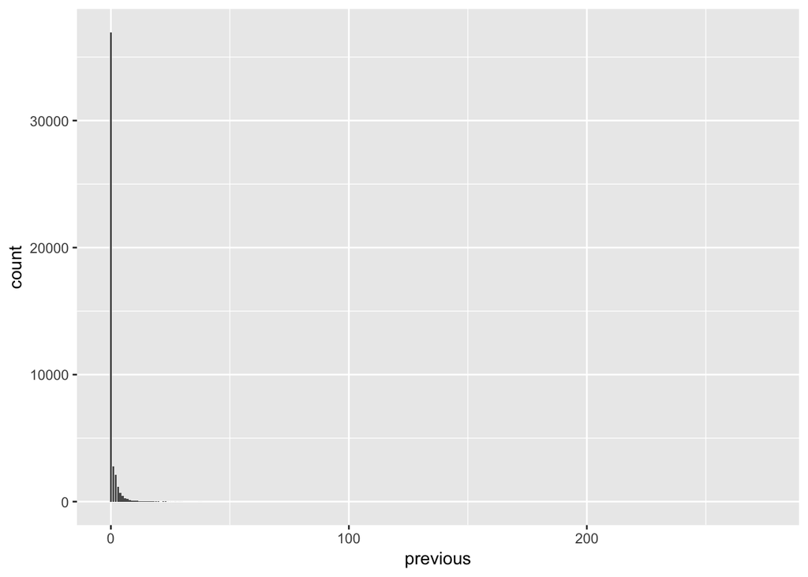

```r
data %>%
    ggplot(aes(previous)) +
    geom_bar()
```

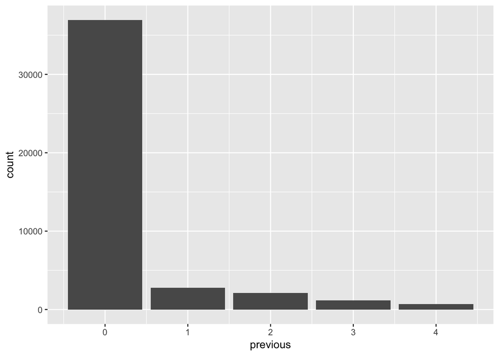

```r
data %>%
    filter(previous < 5) %>%
    ggplot(aes(previous)) +
    geom_bar()
```

Since 82% of all observations in “previous” column are zero, we decided to convert it to binary which translates to 0: not contacted before and 1: contacted before.

```r
data = data %>%
    mutate(previous = ifelse(previous == 0, 0, 1))
data$previous = as.integer(data$previous)
```

```r
num_vars <- c('age', 'balance', 'duration', 'campaign')
```

Outliers in the dataset were detected based on IQR rule.

```r
Outliers <- c()

for(i in num_vars){

  max <- quantile(data[,i],0.75, na.rm=TRUE) + (IQR(data[,i], na.rm=TRUE) * 3 )
  min <- quantile(data[,i],0.25, na.rm=TRUE) - (IQR(data[,i], na.rm=TRUE) * 3 )

  idx <- which(data[,i] < min | data[,i] > max)

  print(paste(i, length(idx), sep=' : '))

  Outliers <- c(Outliers, idx)
}
```

```
## [1] "age : 3"
## [1] "balance : 2443"
## [1] "duration : 1155"
## [1] "campaign : 1462"
```

```r
Outliers <- sort(Outliers)

data <- data[-Outliers,]
```

Target variable “y” and other binary variables were transformed into numerical type.

```r
data$y <- as.integer(as.character(factor(data$y, levels = c("no", "yes"), labels = c("0", "1"))))
```

```r
data$default <- as.integer(as.character(factor(data$default, levels = c("no", "yes"), labels = c("0", "1"))))
data$housing <- as.integer(as.character(factor(data$housing, levels = c("no", "yes"), labels = c("0", "1"))))
data$loan <- as.integer(as.character(factor(data$loan, levels = c("no", "yes"), labels = c("0", "1"))))
```

```r
multi = c('job', 'marital', 'education', 'contact', 'poutcome', 'month')
```

Categorical variables that have more than two distinct values were dummified in order to do a more precise analysis.

```r
data = dummy.data.frame(data, multi, drop = FALSE)
```

Numerical variables were scaled.

```r
data$age = scale(data$age)
data$balance = scale(data$balance)
data$duration = scale(data$duration)
data$campaign = scale(data$campaign)
```

```r
str(data)
```

```
## 'data.frame':    40314 obs. of  47 variables:
##  $ age               : num [1:40314, 1] 1.633 0.306 -0.737 0.59 -0.737 ...
##   ..- attr(*, "scaled:center")= num 40.8
##   ..- attr(*, "scaled:scale")= num 10.5
##  $ jobadmin.         : int  0 0 0 0 0 0 0 0 0 0 ...
##  $ jobblue-collar    : int  0 0 0 1 0 0 0 0 0 0 ...
##  $ jobentrepreneur   : int  0 0 1 0 0 0 0 1 0 0 ...
##  $ jobhousemaid      : int  0 0 0 0 0 0 0 0 0 0 ...
##  $ jobmanagement     : int  1 0 0 0 0 1 1 0 0 0 ...
##  $ jobretired        : int  0 0 0 0 0 0 0 0 1 0 ...
##  $ jobself-employed  : int  0 0 0 0 0 0 0 0 0 0 ...
##  $ jobservices       : int  0 0 0 0 0 0 0 0 0 0 ...
##  $ jobstudent        : int  0 0 0 0 0 0 0 0 0 0 ...
##  $ jobtechnician     : int  0 1 0 0 0 0 0 0 0 1 ...
##  $ jobunemployed     : int  0 0 0 0 0 0 0 0 0 0 ...
```

[output cut: 48 more lines]

## Marketing Analytics Applications

### Train-Test Split

```r
smp_size <- floor(0.75 * nrow(data))
set.seed(123)
train_ind <- sample(seq_len(nrow(data)), size = smp_size)
train <- data[train_ind, ]
test <- data[-train_ind, ]
```

### Logistic Regression

-Fitting the model-

```r
model <- glm(y ~ ., data = train, family = binomial)
```

```r
summary(model)
```

```
##
## Call:
## glm(formula = y ~ ., family = binomial, data = train)
##
## Deviance Residuals:
##     Min       1Q   Median       3Q      Max
## -3.1318  -0.3438  -0.2153  -0.1251   3.4042
##
## Coefficients: (6 not defined because of singularities)
##                     Estimate Std. Error z value Pr(>|z|)
## (Intercept)        -2.531978   0.324333  -7.807 5.87e-15 ***
## age                -0.002235   0.030207  -0.074 0.941027
## jobadmin.           0.315088   0.293597   1.073 0.283181
## `jobblue-collar`    0.018370   0.292982   0.063 0.950004
## jobentrepreneur    -0.149204   0.323086  -0.462 0.644217
## jobhousemaid       -0.194128   0.325367  -0.597 0.550745
## jobmanagement       0.216024   0.291421   0.741 0.458525
## jobretired          0.737298   0.297078   2.482 0.013071 *
## `jobself-employed` -0.079256   0.313054  -0.253 0.800137
## jobservices         0.080595   0.299137   0.269 0.787604
## jobstudent          0.897028   0.307659   2.916 0.003549 **
## jobtechnician       0.184034   0.291439   0.631 0.527736
## jobunemployed       0.108351   0.312188   0.347 0.728538
## jobunknown                NA         NA      NA       NA
## maritaldivorced    -0.126452   0.087937  -1.438 0.150440
## maritalmarried     -0.207266   0.059195  -3.501 0.000463 ***
## maritalsingle             NA         NA      NA       NA
## educationprimary   -0.396738   0.132606  -2.992 0.002773 **
## educationsecondary -0.121475   0.115558  -1.051 0.293167
## educationtertiary   0.057111   0.121433   0.470 0.638133
## educationunknown          NA         NA      NA       NA
## default             0.098597   0.202840   0.486 0.626908
## balance             0.118362   0.021997   5.381 7.42e-08 ***
## housing            -0.762339   0.056055 -13.600  < 2e-16 ***
## loan               -0.476451   0.076939  -6.193 5.92e-10 ***
## contactcellular     1.673170   0.092764  18.037  < 2e-16 ***
## contacttelephone    1.555208   0.130301  11.936  < 2e-16 ***
## contactunknown            NA         NA      NA       NA
## monthapr           -1.005993   0.149288  -6.739 1.60e-11 ***
## monthaug           -1.610066   0.145194 -11.089  < 2e-16 ***
```

[output cut: 12 more lines]

```
## previous            0.698768   1.421252   0.492 0.622962
## poutcomefailure    -0.537251   1.422072  -0.378 0.705583
## poutcomeother      -0.307016   1.423769  -0.216 0.829271
## poutcomesuccess     1.787126   1.422801   1.256 0.209094
## poutcomeunknown           NA         NA      NA       NA
## ---
## Signif. codes:  0 '***' 0.001 '**' 0.01 '*' 0.05 '.' 0.1 ' ' 1
##
## (Dispersion parameter for binomial family taken to be 1)
##
##     Null deviance: 20268  on 30234  degrees of freedom
## Residual deviance: 13058  on 30194  degrees of freedom
## AIC: 13140
##
## Number of Fisher Scoring iterations: 6
```

Since columns maritalsingle, monthsep, jobunknown, educationunknown, contactunknown and poutcomeunknown are highly correlated, the output related to these columns happened to be NA.

```r
model <- glm(y ~ .-maritalsingle -monthsep -jobunknown -educationunknown -contactunknown -poutcomeunknown,
               data = train, family = binomial)
```

```r
summary(model)
```

```
##
## Call:
## glm(formula = y ~ . - maritalsingle - monthsep - jobunknown -
##     educationunknown - contactunknown - poutcomeunknown, family = binomial,
##     data = train)
##
## Deviance Residuals:
##     Min       1Q   Median       3Q      Max
## -3.1318  -0.3438  -0.2153  -0.1251   3.4042
##
## Coefficients:
##                     Estimate Std. Error z value Pr(>|z|)
## (Intercept)        -2.531978   0.324333  -7.807 5.87e-15 ***
## age                -0.002235   0.030207  -0.074 0.941027
## jobadmin.           0.315088   0.293597   1.073 0.283181
## `jobblue-collar`    0.018370   0.292982   0.063 0.950004
## jobentrepreneur    -0.149204   0.323086  -0.462 0.644217
## jobhousemaid       -0.194128   0.325367  -0.597 0.550745
## jobmanagement       0.216024   0.291421   0.741 0.458525
## jobretired          0.737298   0.297078   2.482 0.013071 *
## `jobself-employed` -0.079256   0.313054  -0.253 0.800137
## jobservices         0.080595   0.299137   0.269 0.787604
## jobstudent          0.897028   0.307659   2.916 0.003549 **
## jobtechnician       0.184034   0.291439   0.631 0.527736
## jobunemployed       0.108351   0.312188   0.347 0.728538
## maritaldivorced    -0.126452   0.087937  -1.438 0.150440
## maritalmarried     -0.207266   0.059195  -3.501 0.000463 ***
## educationprimary   -0.396738   0.132606  -2.992 0.002773 **
## educationsecondary -0.121475   0.115558  -1.051 0.293167
## educationtertiary   0.057111   0.121433   0.470 0.638133
## default             0.098597   0.202840   0.486 0.626908
## balance             0.118362   0.021997   5.381 7.42e-08 ***
## housing            -0.762339   0.056055 -13.600  < 2e-16 ***
## loan               -0.476451   0.076939  -6.193 5.92e-10 ***
## contactcellular     1.673170   0.092764  18.037  < 2e-16 ***
## contacttelephone    1.555208   0.130301  11.936  < 2e-16 ***
## monthapr           -1.005993   0.149288  -6.739 1.60e-11 ***
## monthaug           -1.610066   0.145194 -11.089  < 2e-16 ***
## monthdec           -0.289381   0.241264  -1.199 0.230357
## monthfeb           -1.145929   0.152065  -7.536 4.85e-14 ***
```

[output cut: 8 more lines]

```
## campaign           -0.222311   0.029199  -7.614 2.66e-14 ***
## previous            0.698768   1.421252   0.492 0.622962
## poutcomefailure    -0.537251   1.422072  -0.378 0.705583
## poutcomeother      -0.307016   1.423769  -0.216 0.829271
## poutcomesuccess     1.787126   1.422801   1.256 0.209094
## ---
## Signif. codes:  0 '***' 0.001 '**' 0.01 '*' 0.05 '.' 0.1 ' ' 1
##
## (Dispersion parameter for binomial family taken to be 1)
##
##     Null deviance: 20268  on 30234  degrees of freedom
## Residual deviance: 13058  on 30194  degrees of freedom
## AIC: 13140
##
## Number of Fisher Scoring iterations: 6
```

```r
model <- glm(y ~ jobstudent + maritalmarried + educationprimary + balance + housing + loan + contactcellular +
               contacttelephone + monthapr + monthaug + monthfeb + monthjan + monthjul + monthjun + monthmar +
               monthmay + monthnov + duration + campaign,
               data = train, family = binomial)
```

```r
summary(model)
```

```
##
## Call:
## glm(formula = y ~ jobstudent + maritalmarried + educationprimary +
##     balance + housing + loan + contactcellular + contacttelephone +
##     monthapr + monthaug + monthfeb + monthjan + monthjul + monthjun +
##     monthmar + monthmay + monthnov + duration + campaign, family = binomial,
##     data = train)
##
## Deviance Residuals:
##     Min       1Q   Median       3Q      Max
## -2.8598  -0.3794  -0.2378  -0.1293   3.7198
##
## Coefficients:
##                  Estimate Std. Error z value Pr(>|z|)
## (Intercept)      -2.14714    0.11938 -17.986  < 2e-16 ***
## jobstudent        0.74967    0.11094   6.758 1.40e-11 ***
## maritalmarried   -0.14630    0.04640  -3.153  0.00161 **
## educationprimary -0.40724    0.07188  -5.666 1.46e-08 ***
## balance           0.15040    0.02066   7.279 3.37e-13 ***
## housing          -0.85003    0.05252 -16.184  < 2e-16 ***
## loan             -0.56159    0.07455  -7.533 4.95e-14 ***
## contactcellular   2.05088    0.08830  23.225  < 2e-16 ***
## contacttelephone  1.92801    0.12275  15.707  < 2e-16 ***
## monthapr         -1.37115    0.10282 -13.335  < 2e-16 ***
## monthaug         -1.96781    0.09637 -20.420  < 2e-16 ***
## monthfeb         -1.46850    0.10594 -13.861  < 2e-16 ***
## monthjan         -2.62838    0.15346 -17.128  < 2e-16 ***
## monthjul         -2.32390    0.10048 -23.129  < 2e-16 ***
## monthjun         -0.66900    0.10987  -6.089 1.14e-09 ***
## monthmar          0.45924    0.14678   3.129  0.00176 **
## monthmay         -1.67568    0.09628 -17.404  < 2e-16 ***
## monthnov         -2.09371    0.10770 -19.439  < 2e-16 ***
## duration          1.02166    0.01940  52.650  < 2e-16 ***
## campaign         -0.28277    0.02856  -9.901  < 2e-16 ***
## ---
## Signif. codes:  0 '***' 0.001 '**' 0.01 '*' 0.05 '.' 0.1 ' ' 1
##
## (Dispersion parameter for binomial family taken to be 1)
##
##     Null deviance: 20268  on 30234  degrees of freedom
## Residual deviance: 14077  on 30215  degrees of freedom
## AIC: 14117
##
## Number of Fisher Scoring iterations: 6
```

It can be understood that contactcellular, contacttelephone and duration are the variables which have greater affect on subscription.

```r
predicttrains <- predict(model, train[-47], type = 'response')
predictions <- predict(model, test[-47], type = 'response')
```

Then we’ve looked at the performance metrics of the model.

```r
predicted.classes <- ifelse(predicttrains > 0.5, "1", "0")
predicted.classes.test <- ifelse(predictions > 0.5, "1", "0")
```

```r
mean(predicted.classes == train$y)
```

```
## [1] 0.9024971
```

```r
mean(predicted.classes.test == test$y)
```

```
## [1] 0.9028673
```

```r
train$y = factor(train$y)
test$y = factor(test$y)
```

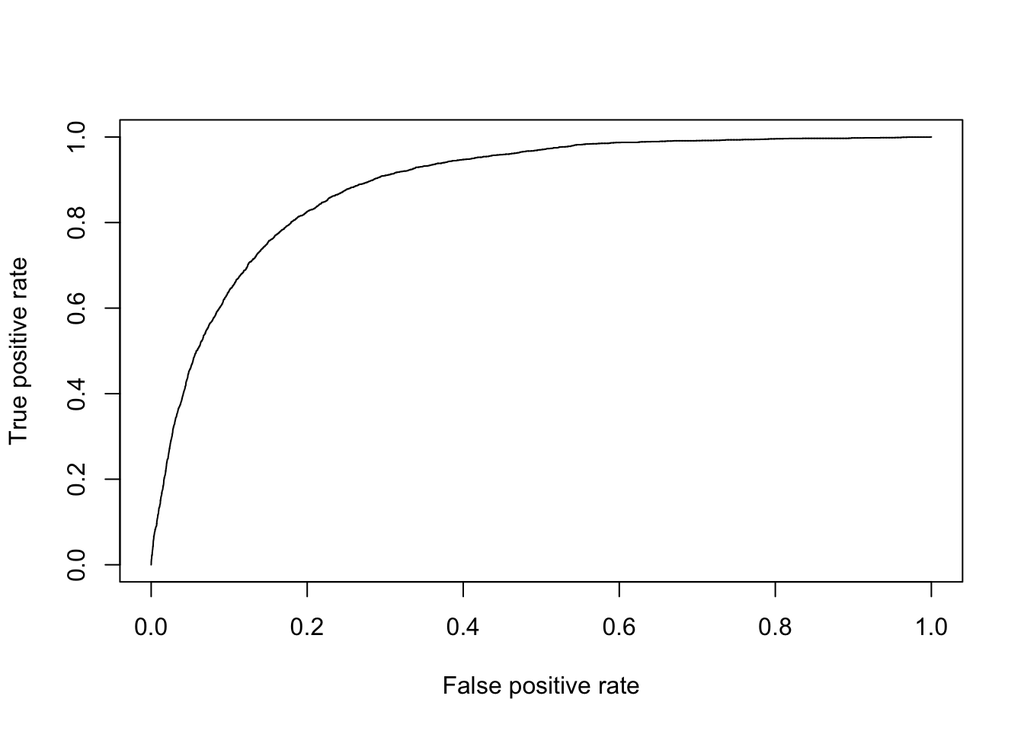

```r
pred = prediction(predicttrains, train$y)
perf = performance(pred, measure = "tpr", x.measure = "fpr")
plot(perf)
```

Confusion Matrix and Statistics:

```r
train_cm <- factor(predicted.classes, levels = levels(as.factor(train[["y"]])))
confusionMatrix(train_cm, as.factor(train[["y"]]))
```

```
## Confusion Matrix and Statistics
##
##           Reference
## Prediction     0     1
##          0 26454  2331
##          1   617   833
##
##                Accuracy : 0.9025
##                  95% CI : (0.8991, 0.9058)
##     No Information Rate : 0.8954
##     P-Value [Acc > NIR] : 2.174e-05
##
##                   Kappa : 0.3161
##
##  Mcnemar's Test P-Value : < 2.2e-16
##
##             Sensitivity : 0.9772
##             Specificity : 0.2633
##          Pos Pred Value : 0.9190
##          Neg Pred Value : 0.5745
##              Prevalence : 0.8954
##          Detection Rate : 0.8749
##    Detection Prevalence : 0.9520
##       Balanced Accuracy : 0.6202
##
##        'Positive' Class : 0
##
```

```r
test_cm <- factor(predicted.classes.test, levels = levels(as.factor(test[["y"]])))
confusionMatrix(test_cm, as.factor(test[["y"]]))
```

```
## Confusion Matrix and Statistics
##
##           Reference
## Prediction    0    1
##          0 8817  787
##          1  192  283
##
##                Accuracy : 0.9029
##                  95% CI : (0.8969, 0.9086)
##     No Information Rate : 0.8938
##     P-Value [Acc > NIR] : 0.001539
##
##                   Kappa : 0.3221
##
##  Mcnemar's Test P-Value : < 2.2e-16
##
##             Sensitivity : 0.9787
##             Specificity : 0.2645
##          Pos Pred Value : 0.9181
##          Neg Pred Value : 0.5958
##              Prevalence : 0.8938
##          Detection Rate : 0.8748
##    Detection Prevalence : 0.9529
##       Balanced Accuracy : 0.6216
##
##        'Positive' Class : 0
##
```

Accuracy score of the model is 0.903. While Sensitivity is 0.979, Specificity is 0.265.

### Decision Tree

For better analysis, complexity parameter was selected as 0.003.

```r
fit <- rpart(train$y ~ ., data = train, method="class", control = rpart.control(cp = 0.003))
```

```r
summary(fit)
```

```
## Call:
## rpart(formula = train$y ~ ., data = train, method = "class",
##     control = rpart.control(cp = 0.003))
##   n= 30235
##
##            CP nsplit rel error    xerror       xstd
## 1 0.087547408      0 1.0000000 1.0000000 0.01682205
## 2 0.032237674      1 0.9124526 0.9124526 0.01615083
## 3 0.003792668      2 0.8802149 0.8814791 0.01590275
## 4 0.003000000     13 0.8305942 0.8669406 0.01578427
##
## Variable importance
##        duration poutcomesuccess             age        monthmar
##              43              40               6               5
##  contactunknown contactcellular         balance        monthmay
##               1               1               1               1
##
## Node number 1: 30235 observations,    complexity param=0.08754741
##   predicted class=0  expected loss=0.1046469  P(node) =1
##     class counts: 27071  3164
##    probabilities: 0.895 0.105
##   left son=2 (29214 obs) right son=3 (1021 obs)
##   Primary splits:
##       poutcomesuccess < 0.5         to the left,  improve=595.8966, (0 missing)
##       duration        < 0.9685519   to the left,  improve=480.6245, (0 missing)
##       previous        < 0.5         to the left,  improve=183.8680, (0 missing)
##       poutcomeunknown < 0.5         to the right, improve=183.4708, (0 missing)
##       age             < 1.870155    to the left,  improve=163.6994, (0 missing)
##   Surrogate splits:
##       age < 4.761374    to the left,  agree=0.966, adj=0.001, (0 split)
##
## Node number 2: 29214 observations,    complexity param=0.003792668
##   predicted class=0  expected loss=0.08608886  P(node) =0.9662312
##     class counts: 26699  2515
##    probabilities: 0.914 0.086
##   left son=4 (26080 obs) right son=5 (3134 obs)
##   Primary splits:
##       duration       < 1.301188    to the left,  improve=447.49100, (0 missing)
##       age            < 1.870155    to the left,  improve=102.93060, (0 missing)
##       monthmar       < 0.5         to the left,  improve= 81.97760, (0 missing)
```

[output cut: 236 more lines]

```
##       monthapr        < 0.5         to the right, agree=0.678, adj=0.219, (0 split)
##       jobblue-collar  < 0.5         to the right, agree=0.631, adj=0.106, (0 split)
##       previous        < 0.5         to the right, agree=0.609, adj=0.053, (0 split)
##       poutcomeunknown < 0.5         to the left,  agree=0.609, adj=0.053, (0 split)
##       poutcomefailure < 0.5         to the right, agree=0.604, adj=0.040, (0 split)
##
## Node number 186: 151 observations
##   predicted class=0  expected loss=0.4503311  P(node) =0.004994212
##     class counts:    83    68
##    probabilities: 0.550 0.450
##
## Node number 187: 215 observations
##   predicted class=1  expected loss=0.3906977  P(node) =0.007110964
##     class counts:    84   131
##    probabilities: 0.391 0.609
```

It can be understood that ‘duration’ and ‘poutcomesuccess’ have the highest variable importance percentages. The longer the last contact duration is, the higher the probability of customer subscripting for the term deposit. Similarly, success of the previous marketing campaign has a significant effect on subscription.

```r
predicted_train = predict(fit, train[-47], type = "class")
predicted_test = predict(fit, test[-47], type = "class")
```

Confusion Matrix:

```r
table = table(test$y, predicted_test)
table
```

```
##    predicted_test
##        0    1
##   0 8848  161
##   1  752  318
```

```r
accuracy = sum(diag(table)) / sum(table)
accuracy
```

```
## [1] 0.9094156
```

Accuracy score of the decision tree model is 0.91.

The visualization of the decision tree as below:

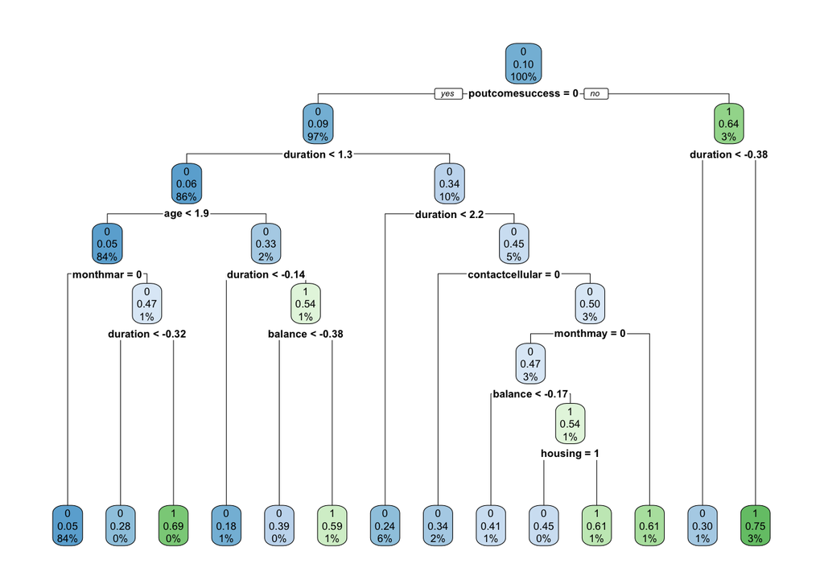

```r
rpart.plot(fit, extra=106)
```